# The Report About Incarcentration in the United State

## Map

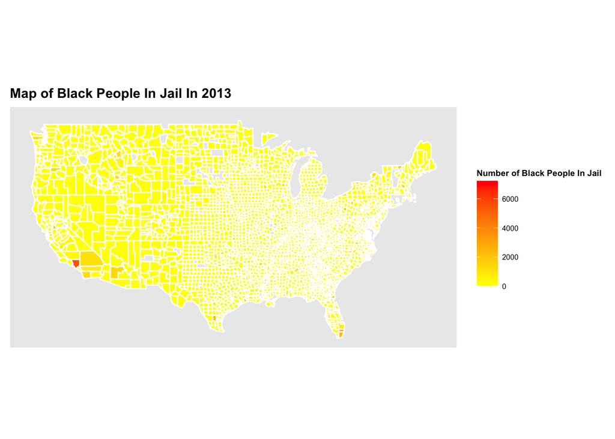

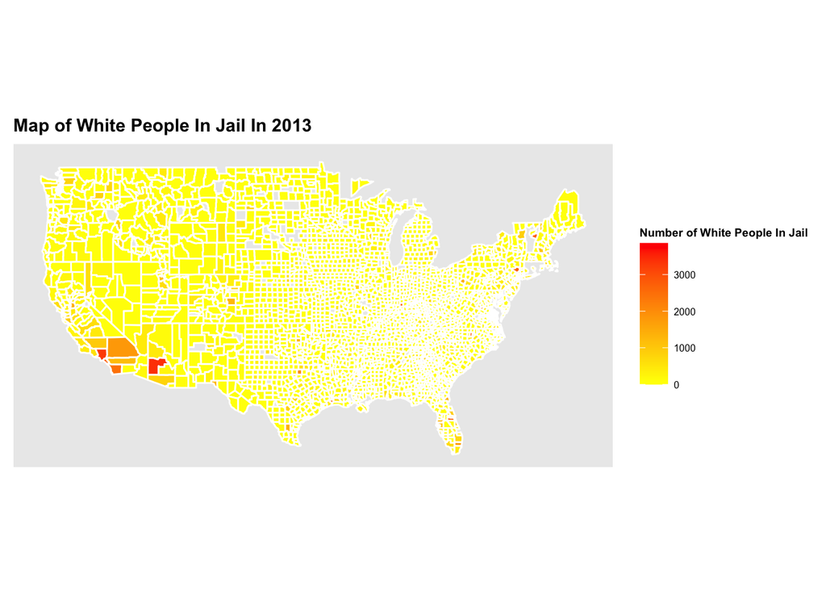

The reason why I include this chart is that I want to compare the distribution of white and black people who are in jail in the United State in 2013. I also want to display which part of the United State contains the highest number of prisoners. From these two maps, we can notice that the highest number of black and white people who are in jail is located in the Southwest part of the United State, especially in California. And, in the middle part of the east of the United State, the number of black and white people who are in jail are both the fewest. Based on these findings, the patterns of distribution of black and white people in jail are pretty similar in 2013 even though the number of black people in jail are twice the number of white people in jail.